# Konnermann Figure 4 Simulations

Author

Alistair Bailey

Published

March 20, 2025

## Introduction

To better understand the expected Coefficients of Variation, here I re-create the simulations for a cylindrical channel in Figure 4 in Konnermann 1999 (Konermann 1999).

I then apply the same analysis for rectangular channel.

I’ve tried to be as explicit as possible so you can check my understanding is correct, but I’ve not added many comments as I ran out of time this week.

## Age distribution function

### Global parameters

Channel geometry:

- $R$ is the radius for a circular channel
- $h$ height and $w$ width for rectangular channel
- $l$ is channel length
- Average velocity $v$
- Maximum velocity at the centre of the channel is $2v$
- Age $a$ is time since particle release
- $\tau = {l \over v}$

### Taylor dispersion to incorporate diffusion

Taylor dispersion is represented by an effective diffusion coefficient `D_eff` that is a function of theoretical diffusion coefficient and the geometry.

Equation 1 is for a circular channel:

$$D_{eff} = D + {R^2v^2\over48D}
\tag{1}$$

where $D$ is the molecular diffusion coefficient, $R$ is the radius $v$ is the average velocity and $48$ is the factor for Poiseuille flow in circular channel.

$$t_{diff} = {R^2\over 3.8D}
\tag{2}$$

where 3.8 is a factor from Taylor’s analysis in tubes.

Equation 3 is for a rectangular channel:

$$D_{eff} = D + {h^2v^2\over KD}
\tag{3}$$

where $h$ is the channel height and factor $K$ depends on the aspect ratio.

And Equation 4 is:

$$t_{diff} = {h^2\over 8D}
\tag{4}$$

where 8 is a factor from Taylor’s analysis in tubes relevant for rectangular channels.

### Circular channel

```r
calculate_age_distribution <- function(age = a, length = l, diffusion_coef = D) {
  tau <- length / v_avg

  # Calculate the Taylor dispersion effective diffusion coefficient
  D_eff <- diffusion_coef + (R^2 * v_avg^2) / (48 * diffusion_coef)

  # Characteristic time for diffusion to be significant across tube radius
  t_diff <- R^2 / (3.8 * diffusion_coef)

  # Dimensionless parameter to determine dispersion regime
  dispersion_number <- tau / t_diff

  if (dispersion_number < 0.1) {
    # Case A: Short length - pure convection dominates (minimal diffusion)
    if (age < length / v_max) {
      return(0)
    }
    return((2 * length^2) / (v_max^2 * age^3)) # Equation 10 from paper
  } else if (dispersion_number >= 0.1 && dispersion_number < 1) {
    # Case B: Transition regime - both convection and diffusion matter
    # Blend analytical solution with Taylor dispersion
    if (age < length / v_max * 0.9) {
      return(0)
    } # Slight adjustment to avoid discontinuity

    # Weight of Taylor dispersion contribution (increases with distance)
    w_taylor <- dispersion_number

    # Analytical solution (convection)
    p_conv <- (2 * length^2) / (v_max^2 * age^3)

    # Taylor dispersion (Gaussian)
    sigma <- sqrt(2 * D_eff * tau) / v_avg
    p_taylor <- (1 / (sigma * sqrt(2 * pi))) * exp(-0.5 * ((age - tau) / sigma)^2)

    # Weighted blend
    return((1 - w_taylor) * p_conv + w_taylor * p_taylor)
  } else {
    # Case C: Long length - Taylor dispersion dominates
    # In this regime, the distribution is Gaussian with centre at tau
    sigma <- sqrt(2 * D_eff * tau) / v_avg
    return((1 / (sigma * sqrt(2 * pi))) * exp(-0.5 * ((age - tau) / sigma)^2))
  }
}
```

### Rectangular channel

```r
calculate_rect_age_distribution <- function(age, length, diffusion_coef, height, width) {
  tau <- length / v_avg
  v_max <- 1.5 * v_avg

  # Calculate dispersion
  t_diff <- height^2 / (8 * diffusion_coef)
  dispersion_number <- tau / t_diff

  # Calculate Taylor dispersion coefficient properly
  aspect_ratio <- width / height
  K <- if (aspect_ratio > 10) 210 else 192
  D_eff <- diffusion_coef + (height^2 * v_avg^2) / (K * diffusion_coef)

  # Peclet number
  Pe <- v_avg * height / diffusion_coef

  # Calculate distribution without arbitrary scaling
  if (age < length / v_max) {
    return(0)
  }

  # Basic distribution shape from convection
  p_conv <- (2 * length^2) / (v_max^2 * (age^3 + 1e-10))

  # Taylor distribution (if applicable)
  sigma <- sqrt(2 * D_eff * tau) / v_avg
  p_taylor <- dnorm(age, mean = tau, sd = sigma)

  # Smooth transition based on dispersion number
  w_taylor <- pmin(1, dispersion_number / 10)

  # Final distribution (blended)
  return((1 - w_taylor) * p_conv + w_taylor * p_taylor)
}
```

## Re-create Konnermann Figure 4

Konnermann simulated a circular channel with $R$ of 37.5 µm and an average velocity $v$ of 0.113 m/s for lengths $l$ of 1, 10 and 100 cm.

Below is the R code using the function to create the data for Figure 4.

Having assigned global parameters, the code creates a table row-wise using `tribble` where the rows consist of 3 columns: a character vector for the condition, numerical vector for the length, and numerical vector for `tau`.

It then uses `crossing()` to create `a_tau`: all combinations for the initial three rows from 0 to 2 by steps of 0.01 such that we go from 3 rows to 603 rows.

The age variable `a` is calculated for each row as a product of `tau` and `a_tau`.

The we use the age distribution function to calculate row-wise the density for the plot using the diffusion coefficient from the manuscript of $D$ of `5e-10` .

Listing 1: Simulate Figure 4 data

```r
# Global parameters
R <- 37.5e-6 # tube radius (um) diameter 75 um
v_avg <- 0.113 # average flow velocity 0.113 m/s
v_max <- 2 * v_avg # maximum velocity at centre (m/s)

fig4_data <- tribble(
  ~position, ~l, ~tau,
  "A: tau = 0.09 s, l = 1 cm", 0.01, 0.09,
  "B: tau = 0.9 s, l = 10 cm", 0.1, 0.9,
  "C: tau = 9 s, l = 100 cm", 1.0, 9
) |>
  crossing(a_tau = seq(0, 2, by = 0.01)) |>
  mutate(a = a_tau * tau) |>
  rowwise() |>
  mutate(density = calculate_age_distribution(a, l, 5e-10)) |>
  ungroup()
```

Figure 1 shows the plot this creates and Figure 2 shows the original plot.

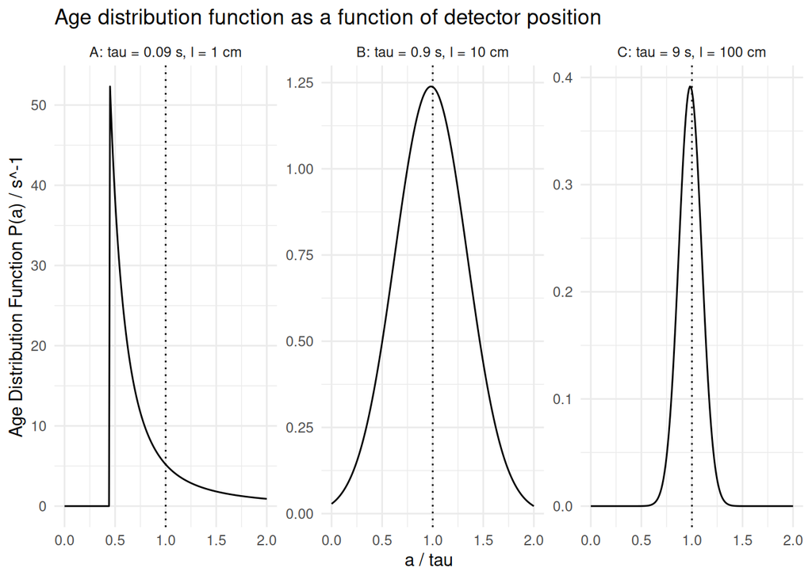

Figure 1: Konnermann Figure 4. As I used a Taylor dispersion model, Panel B deviates from the paper figure.

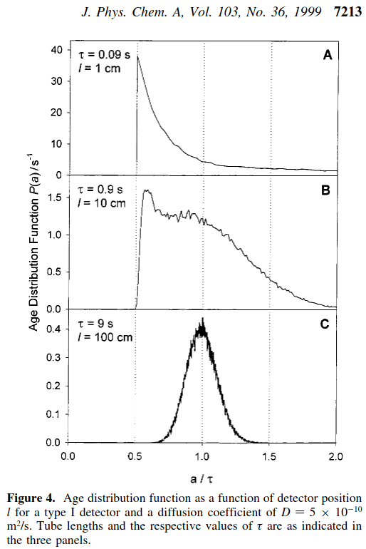

Figure 2: Figure 4 from the Konnermann paper

Table 1 shows the summary statistics for the distributions in Figure 1.

Table 1: Summary statistics for circular channel

| position | l | tau | mean_age | std_dev | cv_percent |
| --- | --- | --- | --- | --- | --- |
| A: tau = 0.09 s, l = 1 cm | 0.01 | 0.09 | 0.0678 | 0.0302 | 44.5 |
| B: tau = 0.9 s, l = 10 cm | 0.1 | 0.9 | 0.8856 | 0.3149 | 35.6 |
| C: tau = 9 s, l = 100 cm | 1 | 9 | 8.8496 | 1.0184 | 11.5 |

## Rectangular channel

### Konnermann parameters

Listing 2: Simulate Figure 5 data

```r
# Global parameters
height <- 70e-6
width <- 140e-6

fig5_data <- tribble(
  ~position, ~l, ~tau,
  "A: tau = 0.09 s, l = 1 cm", 0.01, 0.09,
  "B: tau = 0.9 s, l = 10 cm", 0.1, 0.9,
  "C: tau = 9 s, l = 100 cm", 1.0, 9
) |>
  crossing(a_tau = seq(0, 2, by = 0.01)) |>
  mutate(a = a_tau * tau) |>
  rowwise() |>
  mutate(density = calculate_rect_age_distribution(a, l, 5e-10, height, width)) |>
  ungroup() |> # After calculating all points, normalize the distribution for each position
  group_by(position) |>
  mutate(
    # Numerical integration (trapezoidal rule)
    total_area = sum(density * diff(c(0, a))[1], na.rm = TRUE),
    # Normalize
    density_norm = density / total_area
  ) |>
  ungroup()
```

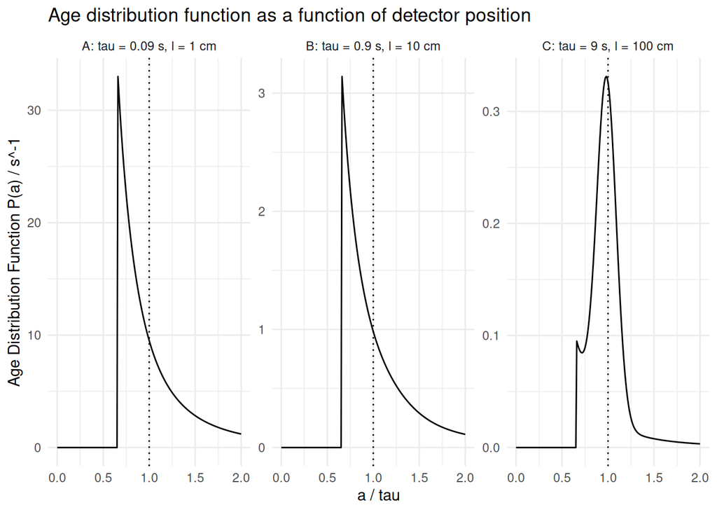

Figure 3

```r
fig5_data |>
  ggplot(aes(x = a_tau, y = density)) +
  geom_line() +
  facet_wrap(~position, scales = "free_y") +
  labs(
    x = "a / tau",
    y = "Age Distribution Function P(a) / s^-1",
    title = "Age distribution function as a function of detector position"
  ) +
  theme_minimal() +
  geom_vline(xintercept = 1, linetype = "dotted")
```

Table 2: Summary statistics for rectangular channel

| position | l | tau | mean_age | std_dev | cv_percent |
| --- | --- | --- | --- | --- | --- |
| A: tau = 0.09 s, l = 1 cm | 0.01 | 0.09 | 0.089 | 0.0285 | 32 |
| B: tau = 0.9 s, l = 10 cm | 0.1 | 0.9 | 0.894 | 0.2818 | 31.5 |
| C: tau = 9 s, l = 100 cm | 1 | 9 | 8.861 | 1.6527 | 18.7 |

### Protein diffusion coefficient

Next I’ll change $D$ to `1e-10` for protein diffusion:

Listing 3: Simulate D = 1e-10 data

```r
# Global parameters
height <- 70e-6
width <- 140e-6
D_p <- 1e-10

dp_data <- tribble(
  ~position, ~l, ~tau,
  "A: tau = 0.09 s, l = 1 cm", 0.01, 0.09,
  "B: tau = 0.9 s, l = 10 cm", 0.1, 0.9,
  "C: tau = 9 s, l = 100 cm", 1.0, 9
) |>
  crossing(a_tau = seq(0, 2, by = 0.01)) |>
  mutate(a = a_tau * tau) |>
  rowwise() |>
  mutate(density = calculate_rect_age_distribution(a, l, D_p, height, width)) |>
  ungroup() |> # After calculating all points, normalize the distribution for each position
  group_by(position) |>
  mutate(
    # Numerical integration (trapezoidal rule)
    total_area = sum(density * diff(c(0, a))[1], na.rm = TRUE),
    # Normalize
    density_norm = density / total_area
  ) |>
  ungroup()
```

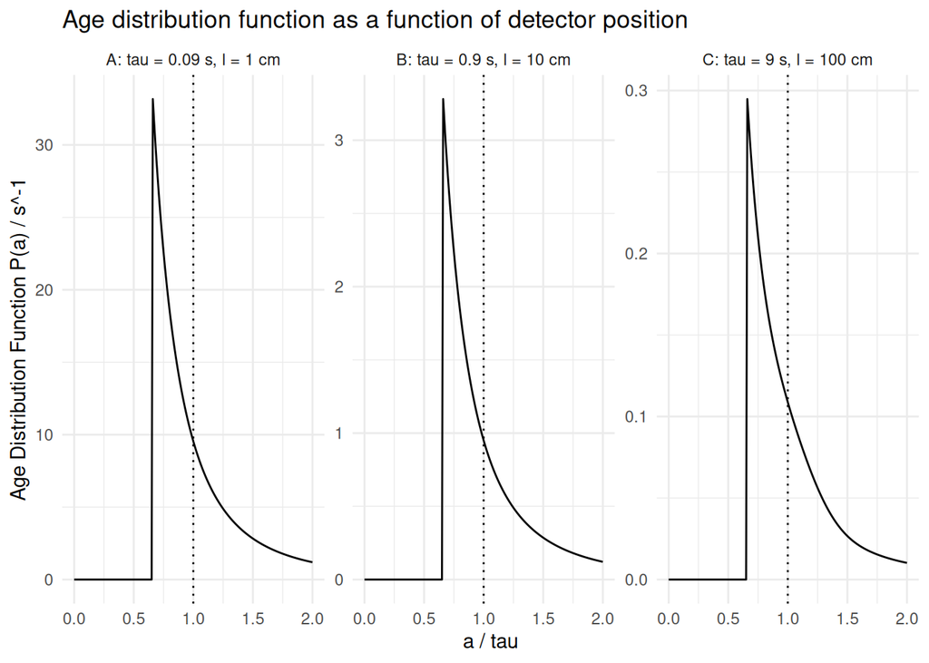

Figure 4

```r
dp_data |>
  ggplot(aes(x = a_tau, y = density)) +
  geom_line() +
  facet_wrap(~position, scales = "free_y") +
  labs(
    x = "a / tau",
    y = "Age Distribution Function P(a) / s^-1",
    title = "Age distribution function as a function of detector position"
  ) +
  theme_minimal() +
  geom_vline(xintercept = 1, linetype = "dotted")
```

Table 3: Summary statistics for rectangular channel with D = 1e-10

| position | l | tau | mean_age | std_dev | cv_percent |
| --- | --- | --- | --- | --- | --- |
| A: tau = 0.09 s, l = 1 cm | 0.01 | 0.09 | 0.0889 | 0.0284 | 32 |
| B: tau = 0.9 s, l = 10 cm | 0.1 | 0.9 | 0.8909 | 0.2854 | 32 |
| C: tau = 9 s, l = 100 cm | 1 | 9 | 8.9335 | 2.7177 | 30.4 |

### Longer times

Next I changed `tau` to 10, 60 and 300 seconds over 1, 6 and 30 metres still with average velocity of 0.113 m/s.

Listing 4: Simulate D = 1e-10 data

```r
# Global parameters
height <- 70e-6
width <- 140e-6
D_p <- 1e-10

dp_data.2 <- tribble(
  ~position, ~l, ~tau,
  "A: tau = 10 s, l = 1 m", 1, 10,
  "B: tau = 60 s, l = 6 m", 6, 60,
  "C: tau = 300 s, l = 30 m", 30, 300
) |>
  crossing(a_tau = seq(0, 2, by = 0.01)) |>
  mutate(a = a_tau * tau) |>
  rowwise() |>
  mutate(density = calculate_rect_age_distribution(a, l, D_p, height, width)) |>
  ungroup() |> # After calculating all points, normalize the distribution for each position
  group_by(position) |>
  mutate(
    # Numerical integration (trapezoidal rule)
    total_area = sum(density * diff(c(0, a))[1], na.rm = TRUE),
    # Normalize
    density_norm = density / total_area
  ) |>
  ungroup()
```

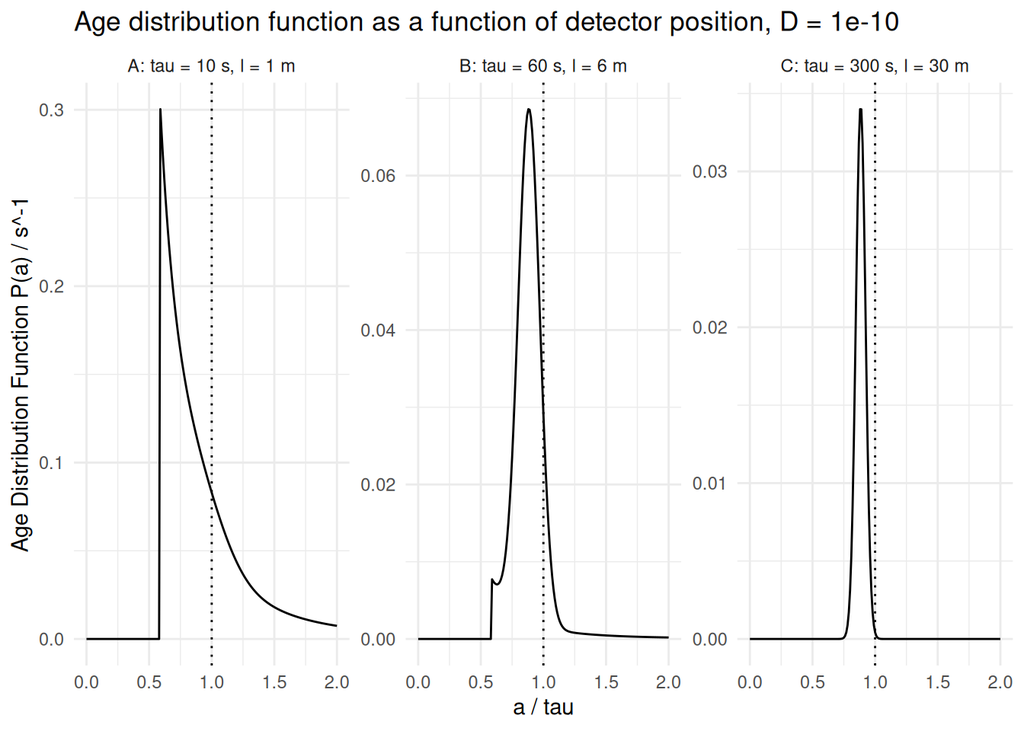

Figure 5

```r
dp_data.2 |>
  ggplot(aes(x = a_tau, y = density)) +
  geom_line() +
  facet_wrap(~position, scales = "free_y") +
  labs(
    x = "a / tau",
    y = "Age Distribution Function P(a) / s^-1",
    title = "Age distribution function as a function of detector position, D = 1e-10"
  ) +
  theme_minimal() +
  geom_vline(xintercept = 1, linetype = "dotted")
```

Table 4: Summary statistics for rectangular channel with D = 1e-10 with tau to 10, 60 and 300 seconds over 1, 6 and 30 metres.

| position | l | tau | mean_age | std_dev | cv_percent |
| --- | --- | --- | --- | --- | --- |
| A: tau = 10 s, l = 1 m | 1 | 10 | 9.08 | 3.03 | 33.34 |
| B: tau = 60 s, l = 6 m | 6 | 60 | 53.26 | 8.33 | 15.64 |
| C: tau = 300 s, l = 30 m | 30 | 300 | 265.49 | 11.64 | 4.38 |

### Faster average velocity

Finally here, I increased $v$ to 0.5 m/s.

Listing 5: Simulate D = 1e-10 data

```r
# Global parameters
height <- 70e-6
width <- 140e-6
D_p <- 1e-10
v_avg <- 0.5 # average flow velocity 0.5 m/s

dp_data.3 <- tribble(
  ~position, ~l, ~tau,
  "A: tau = 0.09 s, l = 1 cm", 0.01, 0.09,
  "B: tau = 0.9 s, l = 10 cm", 0.1, 0.9,
  "C: tau = 9 s, l = 100 cm", 1.0, 9
) |>
  crossing(a_tau = seq(0, 2, by = 0.01)) |>
  mutate(a = a_tau * tau) |>
  rowwise() |>
  mutate(density = calculate_rect_age_distribution(a, l, D_p, height, width)) |>
  ungroup() |> # After calculating all points, normalize the distribution for each position
  group_by(position) |>
  mutate(
    # Numerical integration (trapezoidal rule)
    total_area = sum(density * diff(c(0, a))[1], na.rm = TRUE),
    # Normalize
    density_norm = density / total_area
  ) |>
  ungroup()
```

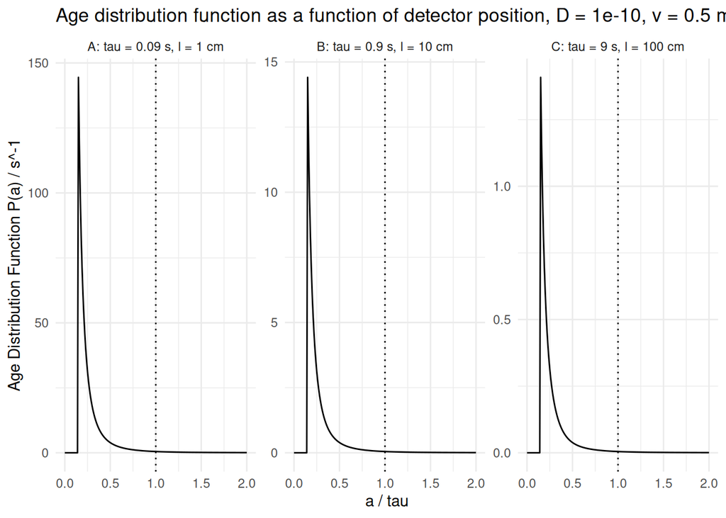

Figure 6

Table 5: Summary statistics for rectangular channel with D = 1e-10, v = 0.5 m/s.

| position | l | tau | mean_age | std_dev | cv_percent |
| --- | --- | --- | --- | --- | --- |
| A: tau = 0.09 s, l = 1 cm | 0.01 | 0.09 | 0.0244 | 0.0175 | 72 |
| B: tau = 0.9 s, l = 10 cm | 0.1 | 0.9 | 0.2439 | 0.1754 | 71.9 |
| C: tau = 9 s, l = 100 cm | 1 | 9 | 2.4355 | 1.7349 | 71.2 |

## References

Konermann, Lars. 1999. “Monitoring Reaction Kinetics in Solution by Continuous-Flow Methods: The Effects of Convection and Molecular Diffusion Under Laminar Flow Conditions.” *The Journal of Physical Chemistry A* 103 (36): 7210–16. https://doi.org/10.1021/jp9908350.